# Your Digest for Friday, Apr 26, 2024 11:59 PM

# Keratocanthoma

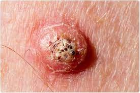

- **Rapidly growing**, **locally destructive** skin tumour with central keratinous plug.
- Occurs in people over 60, with fair skin.
- Clinically indisginguishable from squamous cell carcinoma. Therefore, often called SCC KA-type. [Source](https://dermnetnz.org/topics/keratoacanthoma)  
  Actinic keratosis is a **premalignant lesion** which can transform into **squamous cell carcinoma**.  
  Actinic = means due to sun light.

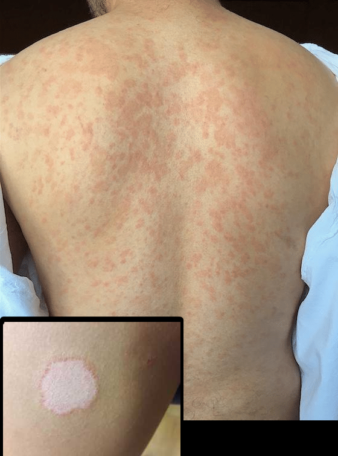

Tends to occurs in young adults or teen.  
Cause unknown.  
May be preceded by flu like symptoms.  
Herald patch occurs first.  
No other systemic effects, resolves spontaneously in about 6 weeks.  
Treatment: General measures, steroid if itching is severe. Can be treated with acylovir due to putative viral aetiology.

- In Kikuchi-Fujimoto disease,the most common histologic finding is lymph node showing **geographic necrosis** with foci of **apoptotic cells** with abundant karyorrhectic fragments surrounded by **histiocytes**. **no neutrophils or eosinophils**
- Treat with terbinafine.
- Superficial infection caused by corynebacterium minutissimum. (bacterial infection)
- First line therapy is topical erythromycin (Mnemonic, erythrasma -> erythromycin) or clindamycin, but topical *miconazole* also works.
- Treated with topical antibacterial, miconazole and if severe, oral erythromycin.
- Pytiriasis is caused by **malassezia** species.

Ghrelin -> increases appetite (also stimulates growth hormone) (Mnemonic: Stomach growls -> ghrelin)

[output not shown]

3. Pleural to Serum LDH > 1.0 *but* pleural to serum protein < 0.5 is characteristic of *pneumocystis jirovecii*. (and urinothorax)[[HIV-AIDS#Pneumocystic jirovecii pneumonia]]
   - **Rheumatoid pleurisy**
   - **Malignant** effusions
   - and Bronchopleural fistula
   - Small asymptomatic pneumothorax may not need an IC tube. [Source](https://www.ncbi.nlm.nih.gov/pmc/articles/PMC3140253/)
4. Trauma
5. Non serous fluid
6. Serous fluid if symptomatic
7. Surgical procedures

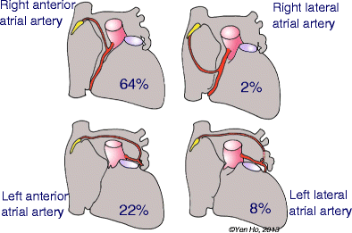

- [Source](https://link.springer.com/article/10.1007/s10840-015-0049-6)
- **Left anterior descending** artery supplies ad *anterior 2/3 of the interventricular septum*.

> The blood supply of the **Left anterolateral papillary muscles** derives from branches of the **left coronary artery**. The blood supply to the **left posteromedial papillary muscles** most commonly derives from the **right coronary artery** [Source](https://www.ncbi.nlm.nih.gov/books/NBK557802/)

# Jugular venous pulse

They will contain *eosinophilic* **Councilman bodies**

[figure not shown]

Portal tracts and lobules are usually infiltrated mainly by lymphocytes.

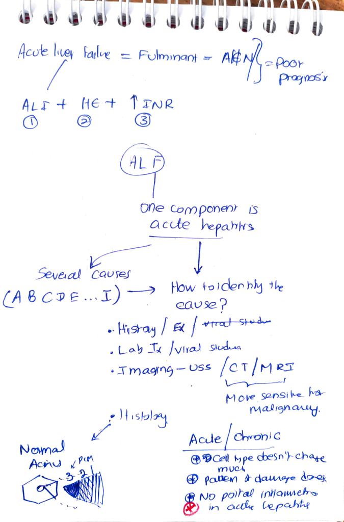

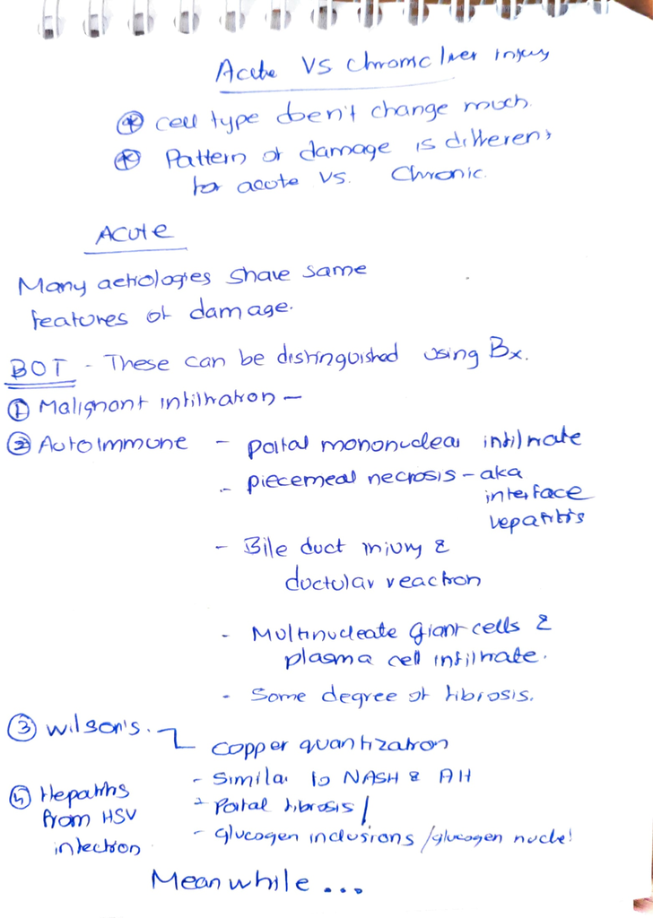

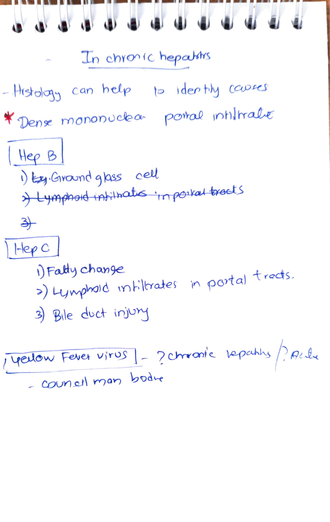

3. **Gastrin** from **G cells** in the **antrum of the pylorus** stimulates *histamine* release from *ECL cells* (fundic glands) (via the **endocrine route**)-> *histamine* stimulates acid secretion from parietal cells

- Most commonly (80%) located in to the **duodenum**.
  - Chronic diarrhoea - excess acid passes into the distal GI tract and causes various things (like **villous atrophy** and malabsorption)
- Cause peptic ulcers; most commonly **solitary ulcers** in the first part of the duodenum.
- There is **hypertrophy of gastric mucosa** secondary to gastrin.
- Dermatology
- Light's criteria